# Qiime_analy

## Within your taxon, what is the richness (number of OTUs/ASVs)?

```r
m.norm %>%
  subset_taxa(Family=="D_4__Oceanospirillaceae") #%>%
```

```
## phyloseq-class experiment-level object
## otu_table()   OTU Table:         [ 28 taxa and 7 samples ]
## sample_data() Sample Data:       [ 7 samples by 22 sample variables ]
## tax_table()   Taxonomy Table:    [ 28 taxa by 7 taxonomic ranks ]
```

```r
  #tax_glom() %>%
  #summary()
```

```r
m.norm %>%
  subset_taxa(Family=="D_4__Oceanospirillaceae") %>%
  otu_table()
```

```
## OTU Table:          [28 taxa and 7 samples]
##                      taxa are rows
##         Saanich_010 Saanich_100 Saanich_120 Saanich_135 Saanich_150
## Asv107            0           0           0           0           0
## Asv120            0          38          14           0           0
## Asv131           42           0           0           0           0
## Asv213         1007          74          44          43          20
## Asv243            0         202         112          67          19
## Asv417            0           0          20           0           0
## Asv476            0           0           0           0           0
## Asv668            0           0           0           0           0
## Asv810          792          84          33          58          13
## Asv1050           0           0          16           0           0
## Asv1152           0          90          25           0          15
## Asv1283          51         144         156          69          64
## Asv1352           0         233         173          50          32
## Asv1414         227         226         116         149          27
## Asv1430           0           0           0           0           0
## Asv1486           0          50          21           0           0
## Asv1490           0          55           0           0           0
## Asv1570          19         135          64          65          52
## Asv1593           0           0          38           0           0
## Asv1797           0           0           0           0           0
## Asv1977           0           0           0           0           0
## Asv2036           0           0           0          31           0
## Asv2097           0         168         119          42          31
## Asv2125           0          64           0           0           0
## Asv2215           0          11           0           0           0
## Asv2281           0         179          89          77          61
## Asv2297           0          47          24           0           0
## Asv2341           0           0           0           0           0
##         Saanich_165 Saanich_200
## Asv107            6           0
## Asv120           39           0
## Asv131            0           0
## Asv213           39           0
## Asv243           41           0
## Asv417            0           0
## Asv476            0          40
## Asv668            0          25
## Asv810            0           0
## Asv1050           0           0
## Asv1152           0           0
## Asv1283         116           0
## Asv1352          46           0
## Asv1414           0           0
## Asv1430           0          39
## Asv1486           0           0
## Asv1490          19           0
## Asv1570          34           0
## Asv1593           0           0
## Asv1797           0          32
## Asv1977           0          24
## Asv2036           0           0
## Asv2097          29           0
## Asv2125           0           0
## Asv2215           0           0
## Asv2281         157           0
## Asv2297          22           0
## Asv2341           0          12
```

## Do the abundances of OTUs/ASVs within your taxon of interest change *significantly* with depth and/or oxygen concentration?

**Depth** General linear model for each OTU  
Asv107

```r
m.norm %>%
  psmelt() %>%
  filter(OTU=="Asv107") %>%

  lm(Abundance ~ Depth_m, .) %>%
  summary()
```

```
##
## Call:
## lm(formula = Abundance ~ Depth_m, data = .)
##
## Residuals:
##       1       2       3       4       5       6       7
##  4.7185 -0.7954 -1.1195 -0.9574  0.3928 -0.5794 -1.6596
##
## Coefficients:
##             Estimate Std. Error t value Pr(>|t|)
## (Intercept) -0.50082    2.21579  -0.226    0.830
## Depth_m      0.01080    0.01611   0.671    0.532
##
## Residual standard error: 2.38 on 5 degrees of freedom
## Multiple R-squared:  0.08252,    Adjusted R-squared:  -0.101
## F-statistic: 0.4497 on 1 and 5 DF,  p-value: 0.5322
```

Asv120

```r
m.norm %>%
  psmelt() %>%
  filter(OTU=="Asv120") %>%

  lm(Abundance ~ Depth_m, .) %>%
  summary()
```

```
##
## Call:
## lm(formula = Abundance ~ Depth_m, data = .)
##
## Residuals:
##       1       2       3       4       5       6       7
##  25.145  25.560   1.124 -14.617 -10.481 -13.202 -13.529
##
## Coefficients:
##             Estimate Std. Error t value Pr(>|t|)
## (Intercept) 10.26350   18.47249   0.556    0.602
## Depth_m      0.02177    0.13429   0.162    0.878
##
## Residual standard error: 19.84 on 5 degrees of freedom
## Multiple R-squared:  0.005227,   Adjusted R-squared:  -0.1937
## F-statistic: 0.02627 on 1 and 5 DF,  p-value: 0.8776
```

Asv131

```r
m.norm %>%
  psmelt() %>%
  filter(OTU=="Asv131") %>%

  lm(Abundance ~ Depth_m, .) %>%
  summary()
```

```
##
## Call:
## lm(formula = Abundance ~ Depth_m, data = .)
##
## Residuals:
##        1        2        3        4        5        6        7
##  10.2285   2.7496  10.5447  -0.5912 -11.7270  -7.2727  -3.9319
##
## Coefficients:
##             Estimate Std. Error t value Pr(>|t|)
## (Intercept) 33.99869    8.63139   3.939   0.0110 *
## Depth_m     -0.22272    0.06275  -3.549   0.0164 *
## ---
## Signif. codes:  0 '***' 0.001 '**' 0.01 '*' 0.05 '.' 0.1 ' ' 1
##
## Residual standard error: 9.269 on 5 degrees of freedom
## Multiple R-squared:  0.7159, Adjusted R-squared:  0.6591
## F-statistic:  12.6 on 1 and 5 DF,  p-value: 0.0164
```

Asv213

```r
m.norm %>%
  psmelt() %>%
  filter(OTU=="Asv213") %>%

  lm(Abundance ~ Depth_m, .) %>%
  summary()
```

```
##
## Call:
## lm(formula = Abundance ~ Depth_m, data = .)
##
## Residuals:
##       1       2       3       4       5       6       7
##  215.21 -238.29 -161.73  -82.81   73.02  -25.89  220.50
##
## Coefficients:
##             Estimate Std. Error t value Pr(>|t|)
## (Intercept)  845.073    181.870   4.647   0.0056 **
## Depth_m       -5.328      1.322  -4.030   0.0100 *
## ---
## Signif. codes:  0 '***' 0.001 '**' 0.01 '*' 0.05 '.' 0.1 ' ' 1
##
## Residual standard error: 195.3 on 5 degrees of freedom
## Multiple R-squared:  0.7646, Adjusted R-squared:  0.7175
## F-statistic: 16.24 on 1 and 5 DF,  p-value: 0.01002
```

Asv243

```r
m.norm %>%
  psmelt() %>%
  filter(OTU=="Asv243") %>%

  lm(Abundance ~ Depth_m, .) %>%
  summary()
```

```
##
## Call:
## lm(formula = Abundance ~ Depth_m, data = .)
##
## Residuals:
##       1       2       3       4       5       6       7
## 135.300  48.178   5.336 -16.347 -40.505 -52.311 -79.651
##
## Coefficients:
##             Estimate Std. Error t value Pr(>|t|)
## (Intercept)  81.0897    74.0794   1.095    0.324
## Depth_m      -0.1439     0.5385  -0.267    0.800
##
## Residual standard error: 79.55 on 5 degrees of freedom
## Multiple R-squared:  0.01408,    Adjusted R-squared:  -0.1831
## F-statistic: 0.07139 on 1 and 5 DF,  p-value: 0.8
```

Asv417

```r
m.norm %>%
  psmelt() %>%
  filter(OTU=="Asv417") %>%

  lm(Abundance ~ Depth_m, .) %>%
  summary()
```

```
##
## Call:
## lm(formula = Abundance ~ Depth_m, data = .)
##
## Residuals:
##      1      2      3      4      5      6      7
## 17.113 -2.651 -3.463 -2.468 -2.809 -2.992 -2.730
##
## Coefficients:
##              Estimate Std. Error t value Pr(>|t|)
## (Intercept)  3.515548   7.704200   0.456    0.667
## Depth_m     -0.005237   0.056008  -0.094    0.929
##
## Residual standard error: 8.274 on 5 degrees of freedom
## Multiple R-squared:  0.001746,   Adjusted R-squared:  -0.1979
## F-statistic: 0.008744 on 1 and 5 DF,  p-value: 0.9291
```

Asv476

```r
m.norm %>%
  psmelt() %>%
  filter(OTU=="Asv476") %>%

  lm(Abundance ~ Depth_m, .) %>%
  summary()
```

```
##
## Call:
## lm(formula = Abundance ~ Depth_m, data = .)
##
## Residuals:
##       1       2       3       4       5       6       7
##  24.170  -4.936  -6.979 -11.064  -2.213  -9.021  10.043
##
## Coefficients:
##              Estimate Std. Error t value Pr(>|t|)
## (Intercept) -11.40426   12.94853  -0.881    0.419
## Depth_m       0.13617    0.09413   1.447    0.208
##
## Residual standard error: 13.91 on 5 degrees of freedom
## Multiple R-squared:  0.295,  Adjusted R-squared:  0.154
## F-statistic: 2.093 on 1 and 5 DF,  p-value: 0.2077
```

Asv668

```r
m.norm %>%
  psmelt() %>%
  filter(OTU=="Asv668") %>%

  lm(Abundance ~ Depth_m, .) %>%
  summary()
```

```
##
## Call:
## lm(formula = Abundance ~ Depth_m, data = .)
##
## Residuals:
##      1      2      3      4      5      6      7
## 15.106 -1.383 -6.915 -5.638 -4.362 -3.085  6.277
##
## Coefficients:
##             Estimate Std. Error t value Pr(>|t|)
## (Intercept) -7.12766    8.09283  -0.881    0.419
## Depth_m      0.08511    0.05883   1.447    0.208
##
## Residual standard error: 8.691 on 5 degrees of freedom
## Multiple R-squared:  0.295,  Adjusted R-squared:  0.154
## F-statistic: 2.093 on 1 and 5 DF,  p-value: 0.2077
```

Asv810

```r
m.norm %>%
  psmelt() %>%
  filter(OTU=="Asv810") %>%

  lm(Abundance ~ Depth_m, .) %>%
  summary()
```

```
##
## Call:
## lm(formula = Abundance ~ Depth_m, data = .)
##
## Residuals:
##       1       2       3       4       5       6       7
##  158.10 -165.76  -42.37 -131.39  -23.34  177.07   27.68
##
## Coefficients:
##             Estimate Std. Error t value Pr(>|t|)
## (Intercept) 676.5840   134.4226   5.033  0.00399 **
## Depth_m      -4.2683     0.9772  -4.368  0.00724 **
## ---
## Signif. codes:  0 '***' 0.001 '**' 0.01 '*' 0.05 '.' 0.1 ' ' 1
##
## Residual standard error: 144.4 on 5 degrees of freedom
## Multiple R-squared:  0.7923, Adjusted R-squared:  0.7508
## F-statistic: 19.08 on 1 and 5 DF,  p-value: 0.007237
```

Asv1050

```r
m.norm %>%
  psmelt() %>%
  filter(OTU=="Asv1050") %>%

  lm(Abundance ~ Depth_m, .) %>%
  summary()
```

```
##
## Call:
## lm(formula = Abundance ~ Depth_m, data = .)
##
## Residuals:
##      1      2      3      4      5      6      7
## 13.690 -2.247 -2.121 -2.771 -2.184 -2.393 -1.974
##
## Coefficients:
##             Estimate Std. Error t value Pr(>|t|)
## (Intercept)  2.81244    6.16336   0.456    0.667
## Depth_m     -0.00419    0.04481  -0.094    0.929
##
## Residual standard error: 6.619 on 5 degrees of freedom
## Multiple R-squared:  0.001746,   Adjusted R-squared:  -0.1979
## F-statistic: 0.008744 on 1 and 5 DF,  p-value: 0.9291
```

Asv1152

```r
m.norm %>%
  psmelt() %>%
  filter(OTU=="Asv1152") %>%

  lm(Abundance ~ Depth_m, .) %>%
  summary()
```

```
##
## Call:
## lm(formula = Abundance ~ Depth_m, data = .)
##
## Residuals:
##       1       2       3       4       5       6       7
##  68.962   5.881  -1.242 -29.669 -11.447 -14.804 -17.681
##
## Coefficients:
##             Estimate Std. Error t value Pr(>|t|)
## (Intercept) 30.62848   33.14541   0.924    0.398
## Depth_m     -0.09591    0.24096  -0.398    0.707
##
## Residual standard error: 35.59 on 5 degrees of freedom
## Multiple R-squared:  0.03071,    Adjusted R-squared:  -0.1631
## F-statistic: 0.1584 on 1 and 5 DF,  p-value: 0.707
```

Asv1283

```r
m.norm %>%
  psmelt() %>%
  filter(OTU=="Asv1283") %>%

  lm(Abundance ~ Depth_m, .) %>%
  summary()
```

```
##
## Call:
## lm(formula = Abundance ~ Depth_m, data = .)
##
## Residuals:
##      1      2      3      4      5      6      7
##  69.31  53.87  37.03 -15.12 -17.55 -54.57 -72.97
##
## Coefficients:
##             Estimate Std. Error t value Pr(>|t|)
## (Intercept) 107.2812    55.7393   1.925    0.112
## Depth_m      -0.1716     0.4052  -0.423    0.690
##
## Residual standard error: 59.86 on 5 degrees of freedom
## Multiple R-squared:  0.03461,    Adjusted R-squared:  -0.1585
## F-statistic: 0.1792 on 1 and 5 DF,  p-value: 0.6896
```

Asv1352

```r
m.norm %>%
  psmelt() %>%
  filter(OTU=="Asv1352") %>%

  lm(Abundance ~ Depth_m, .) %>%
  summary()
```

```
##
## Call:
## lm(formula = Abundance ~ Depth_m, data = .)
##
## Residuals:
##      1      2      3      4      5      6      7
## 152.08  95.68 -24.61 -23.21 -39.91 -62.90 -97.13
##
## Coefficients:
##             Estimate Std. Error t value Pr(>|t|)
## (Intercept)  98.9349    91.6288    1.08    0.330
## Depth_m      -0.1802     0.6661   -0.27    0.798
##
## Residual standard error: 98.4 on 5 degrees of freedom
## Multiple R-squared:  0.01442,    Adjusted R-squared:  -0.1827
## F-statistic: 0.07315 on 1 and 5 DF,  p-value: 0.7976
```

Asv1414

```r
m.norm %>%
  psmelt() %>%
  filter(OTU=="Asv1414") %>%

  lm(Abundance ~ Depth_m, .) %>%
  summary()
```

```
##
## Call:
## lm(formula = Abundance ~ Depth_m, data = .)
##
## Residuals:
##       1       2       3       4       5       6       7
## -42.235  83.392  55.636   1.532 -45.259 -51.155  -1.911
##
## Coefficients:
##             Estimate Std. Error t value Pr(>|t|)
## (Intercept) 283.3051    53.5000   5.295   0.0032 **
## Depth_m      -1.4070     0.3889  -3.618   0.0153 *
## ---
## Signif. codes:  0 '***' 0.001 '**' 0.01 '*' 0.05 '.' 0.1 ' ' 1
##
## Residual standard error: 57.45 on 5 degrees of freedom
## Multiple R-squared:  0.7235, Adjusted R-squared:  0.6683
## F-statistic: 13.09 on 1 and 5 DF,  p-value: 0.01526
```

Asv1430

```r
m.norm %>%
  psmelt() %>%
  filter(OTU=="Asv1430") %>%

  lm(Abundance ~ Depth_m, .) %>%
  summary()
```

```
##
## Call:
## lm(formula = Abundance ~ Depth_m, data = .)
##
## Residuals:
##       1       2       3       4       5       6       7
##  23.566   9.791  -4.813  -2.157  -6.804  -8.796 -10.787
##
## Coefficients:
##              Estimate Std. Error t value Pr(>|t|)
## (Intercept) -11.11915   12.62482  -0.881    0.419
## Depth_m       0.13277    0.09178   1.447    0.208
##
## Residual standard error: 13.56 on 5 degrees of freedom
## Multiple R-squared:  0.295,  Adjusted R-squared:  0.154
## F-statistic: 2.093 on 1 and 5 DF,  p-value: 0.2077
```

Asv1486

```r
m.norm %>%
  psmelt() %>%
  filter(OTU=="Asv1486") %>%

  lm(Abundance ~ Depth_m, .) %>%
  summary()
```

```
##
## Call:
## lm(formula = Abundance ~ Depth_m, data = .)
##
## Residuals:
##       1       2       3       4       5       6       7
##  38.201  10.489  -5.357  -7.612  -8.578 -17.597  -9.545
##
## Coefficients:
##             Estimate Std. Error t value Pr(>|t|)
## (Intercept) 18.24124   19.22078   0.949    0.386
## Depth_m     -0.06442    0.13973  -0.461    0.664
##
## Residual standard error: 20.64 on 5 degrees of freedom
## Multiple R-squared:  0.04077,    Adjusted R-squared:  -0.1511
## F-statistic: 0.2125 on 1 and 5 DF,  p-value: 0.6641
```

Asv1490

```r
m.norm %>%
  psmelt() %>%
  filter(OTU=="Asv1490") %>%

  lm(Abundance ~ Depth_m, .) %>%
  summary()
```

```
##
## Call:
## lm(formula = Abundance ~ Depth_m, data = .)
##
## Residuals:
##       1       2       3       4       5       6       7
##  43.642   9.631 -10.287  -8.298  -9.828 -10.746 -14.113
##
## Coefficients:
##             Estimate Std. Error t value Pr(>|t|)
## (Intercept) 14.41899   21.16585   0.681    0.526
## Depth_m     -0.03061    0.15387  -0.199    0.850
##
## Residual standard error: 22.73 on 5 degrees of freedom
## Multiple R-squared:  0.00785,    Adjusted R-squared:  -0.1906
## F-statistic: 0.03956 on 1 and 5 DF,  p-value: 0.8502
```

Asv1570

```r
m.norm %>%
  psmelt() %>%
  filter(OTU=="Asv1570") %>%

  lm(Abundance ~ Depth_m, .) %>%
  summary()
```

```
##
## Call:
## lm(formula = Abundance ~ Depth_m, data = .)
##
## Residuals:
##       1       2       3       4       5       6       7
##  78.947  13.491  10.544   2.439 -13.613 -48.740 -43.068
##
## Coefficients:
##             Estimate Std. Error t value Pr(>|t|)
## (Intercept)  69.0386    43.5720   1.584    0.174
## Depth_m      -0.1299     0.3168  -0.410    0.699
##
## Residual standard error: 46.79 on 5 degrees of freedom
## Multiple R-squared:  0.03252,    Adjusted R-squared:  -0.161
## F-statistic: 0.1681 on 1 and 5 DF,  p-value: 0.6988
```

Asv1593

```r
m.norm %>%
  psmelt() %>%
  filter(OTU=="Asv1593") %>%

  lm(Abundance ~ Depth_m, .) %>%
  summary()
```

```
##
## Call:
## lm(formula = Abundance ~ Depth_m, data = .)
##
## Residuals:
##      1      2      3      4      5      6      7
## 32.515 -5.187 -5.684 -6.580 -5.038 -5.336 -4.689
##
## Coefficients:
##              Estimate Std. Error t value Pr(>|t|)
## (Intercept)  6.679542  14.637980   0.456    0.667
## Depth_m     -0.009951   0.106415  -0.094    0.929
##
## Residual standard error: 15.72 on 5 degrees of freedom
## Multiple R-squared:  0.001746,   Adjusted R-squared:  -0.1979
## F-statistic: 0.008744 on 1 and 5 DF,  p-value: 0.9291
```

Asv1797

```r
m.norm %>%
  psmelt() %>%
  filter(OTU=="Asv1797") %>%

  lm(Abundance ~ Depth_m, .) %>%
  summary()
```

```
##
## Call:
## lm(formula = Abundance ~ Depth_m, data = .)
##
## Residuals:
##      1      2      3      4      5      6      7
## 19.336 -8.851 -5.583 -7.217 -1.770 -3.949  8.034
##
## Coefficients:
##             Estimate Std. Error t value Pr(>|t|)
## (Intercept) -9.12340   10.35883  -0.881    0.419
## Depth_m      0.10894    0.07531   1.447    0.208
##
## Residual standard error: 11.12 on 5 degrees of freedom
## Multiple R-squared:  0.295,  Adjusted R-squared:  0.154
## F-statistic: 2.093 on 1 and 5 DF,  p-value: 0.2077
```

Asv1977

```r
m.norm %>%
  psmelt() %>%
  filter(OTU=="Asv1977") %>%

  lm(Abundance ~ Depth_m, .) %>%
  summary()
```

```
##
## Call:
## lm(formula = Abundance ~ Depth_m, data = .)
##
## Residuals:
##      1      2      3      4      5      6      7
## 14.502 -4.187  6.026 -1.328 -6.638 -5.413 -2.962
##
## Coefficients:
##             Estimate Std. Error t value Pr(>|t|)
## (Intercept) -6.84255    7.76912  -0.881    0.419
## Depth_m      0.08170    0.05648   1.447    0.208
##
## Residual standard error: 8.343 on 5 degrees of freedom
## Multiple R-squared:  0.295,  Adjusted R-squared:  0.154
## F-statistic: 2.093 on 1 and 5 DF,  p-value: 0.2077
```

Asv2036

```r
m.norm %>%
  psmelt() %>%
  filter(OTU=="Asv2036") %>%

  lm(Abundance ~ Depth_m, .) %>%
  summary()
```

```
##
## Call:
## lm(formula = Abundance ~ Depth_m, data = .)
##
## Residuals:
##      1      2      3      4      5      6      7
## 26.449 -4.947 -2.902 -4.749 -4.353 -4.089 -5.409
##
## Coefficients:
##             Estimate Std. Error t value Pr(>|t|)
## (Intercept)  2.77021   11.92437   0.232    0.826
## Depth_m      0.01319    0.08669   0.152    0.885
##
## Residual standard error: 12.81 on 5 degrees of freedom
## Multiple R-squared:  0.00461,    Adjusted R-squared:  -0.1945
## F-statistic: 0.02316 on 1 and 5 DF,  p-value: 0.885
```

Asv2097

```r
m.norm %>%
  psmelt() %>%
  filter(OTU=="Asv2097") %>%

  lm(Abundance ~ Depth_m, .) %>%
  summary()
```

```
##
## Call:
## lm(formula = Abundance ~ Depth_m, data = .)
##
## Residuals:
##      1      2      3      4      5      6      7
## 109.23  62.72 -12.41 -21.55 -21.68 -69.98 -46.32
##
## Coefficients:
##             Estimate Std. Error t value Pr(>|t|)
## (Intercept)  71.2291    64.5079   1.104    0.320
## Depth_m      -0.1245     0.4690  -0.266    0.801
##
## Residual standard error: 69.28 on 5 degrees of freedom
## Multiple R-squared:  0.01391,    Adjusted R-squared:  -0.1833
## F-statistic: 0.07054 on 1 and 5 DF,  p-value: 0.8012
```

Asv2125

```r
m.norm %>%
  psmelt() %>%
  filter(OTU=="Asv2125") %>%

  lm(Abundance ~ Depth_m, .) %>%
  summary()
```

```
##
## Call:
## lm(formula = Abundance ~ Depth_m, data = .)
##
## Residuals:
##       1       2       3       4       5       6       7
##  52.918 -17.870  -6.180  -7.311  -8.443  -9.574  -3.540
##
## Coefficients:
##             Estimate Std. Error t value Pr(>|t|)
## (Intercept) 18.62390   24.23491   0.768    0.477
## Depth_m     -0.07542    0.17618  -0.428    0.686
##
## Residual standard error: 26.03 on 5 degrees of freedom
## Multiple R-squared:  0.03535,    Adjusted R-squared:  -0.1576
## F-statistic: 0.1832 on 1 and 5 DF,  p-value: 0.6864
```

Asv2215

```r
m.norm %>%
  psmelt() %>%
  filter(OTU=="Asv2215") %>%

  lm(Abundance ~ Depth_m, .) %>%
  summary()
```

```
##
## Call:
## lm(formula = Abundance ~ Depth_m, data = .)
##
## Residuals:
##       1       2       3       4       5       6       7
##  9.0953 -1.4511 -1.0622 -0.6085 -3.0714 -1.2566 -1.6455
##
## Coefficients:
##             Estimate Std. Error t value Pr(>|t|)
## (Intercept)  3.20098    4.16538   0.768    0.477
## Depth_m     -0.01296    0.03028  -0.428    0.686
##
## Residual standard error: 4.473 on 5 degrees of freedom
## Multiple R-squared:  0.03535,    Adjusted R-squared:  -0.1576
## F-statistic: 0.1832 on 1 and 5 DF,  p-value: 0.6864
```

Asv2281

```r
m.norm %>%
  psmelt() %>%
  filter(OTU=="Asv2281") %>%

  lm(Abundance ~ Depth_m, .) %>%
  summary()
```

```
##
## Call:
## lm(formula = Abundance ~ Depth_m, data = .)
##
## Residuals:
##       1       2       3       4       5       6       7
## 102.405  70.715   9.423  -4.813 -23.049 -63.179 -91.502
##
## Coefficients:
##             Estimate Std. Error t value Pr(>|t|)
## (Intercept)  61.6887    70.2964   0.878    0.420
## Depth_m       0.1491     0.5110   0.292    0.782
##
## Residual standard error: 75.49 on 5 degrees of freedom
## Multiple R-squared:  0.01673,    Adjusted R-squared:  -0.1799
## F-statistic: 0.08508 on 1 and 5 DF,  p-value: 0.7822
```

Asv2297

```r
m.norm %>%
  psmelt() %>%
  filter(OTU=="Asv2297") %>%

  lm(Abundance ~ Depth_m, .) %>%
  summary()
```

```
##
## Call:
## lm(formula = Abundance ~ Depth_m, data = .)
##
## Residuals:
##       1       2       3       4       5       6       7
##  33.147  10.588   9.581 -15.839 -13.081 -12.750 -11.647
##
## Coefficients:
##             Estimate Std. Error t value Pr(>|t|)
## (Intercept) 16.05925   18.72956   0.857    0.430
## Depth_m     -0.02206    0.13616  -0.162    0.878
##
## Residual standard error: 20.11 on 5 degrees of freedom
## Multiple R-squared:  0.005223,   Adjusted R-squared:  -0.1937
## F-statistic: 0.02625 on 1 and 5 DF,  p-value: 0.8776
```

Asv2341

```r
m.norm %>%
  psmelt() %>%
  filter(OTU=="Asv2341") %>%

  lm(Abundance ~ Depth_m, .) %>%
  summary()
```

```
##
## Call:
## lm(formula = Abundance ~ Depth_m, data = .)
##
## Residuals:
##       1       2       3       4       5       6       7
##  7.2511 -2.0936 -1.4809 -3.3191 -2.7064  3.0128 -0.6638
##
## Coefficients:
##             Estimate Std. Error t value Pr(>|t|)
## (Intercept) -3.42128    3.88456  -0.881    0.419
## Depth_m      0.04085    0.02824   1.447    0.208
##
## Residual standard error: 4.172 on 5 degrees of freedom
## Multiple R-squared:  0.295,  Adjusted R-squared:  0.154
## F-statistic: 2.093 on 1 and 5 DF,  p-value: 0.2077
```

**Repeat for all OTUs within domain and then correct for multiple comparisons.**

This is all made up p-values.

```r
p.adjust(c(0.501, 0.031, 0.005, 0.324), method="fdr")
```

```
## [1] 0.501 0.062 0.020 0.432
```

Plots to go along with these tests.

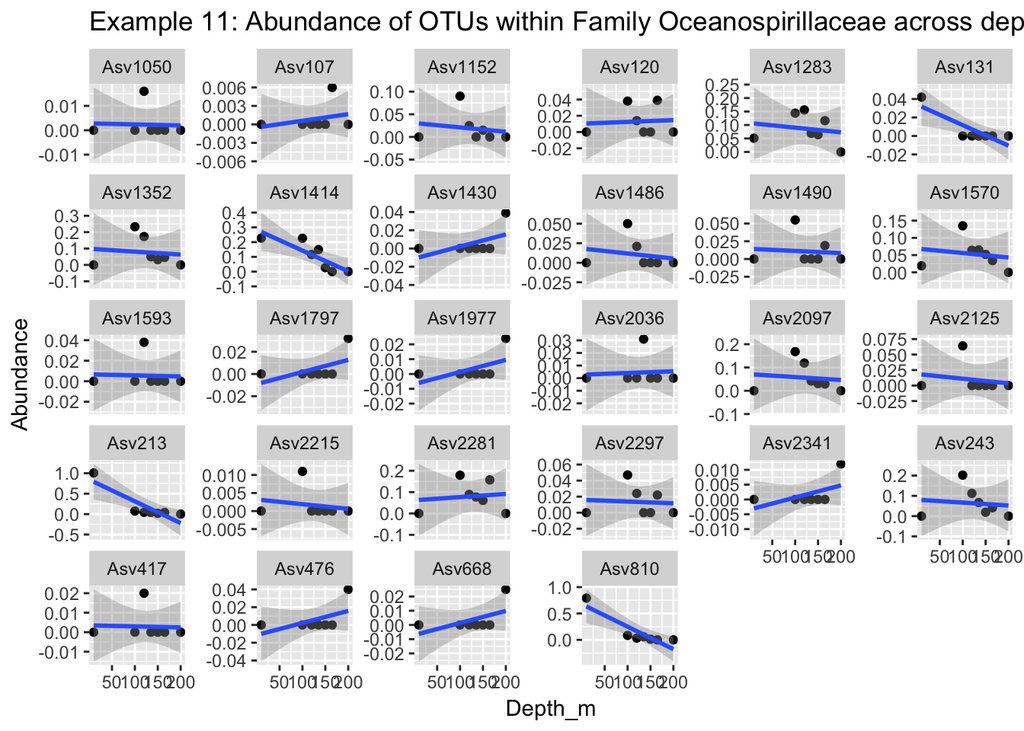

```r
m.perc %>%
  subset_taxa(Family=="D_4__Oceanospirillaceae") %>%
  psmelt() %>%

ggplot() +
  geom_point(aes(x=Depth_m, y=Abundance)) +
  geom_smooth(method='lm', aes(x=Depth_m, y=Abundance)) +
  facet_wrap(~OTU, scales="free_y") +
  labs(title="Example 11: Abundance of OTUs within Family Oceanospirillaceae across depth")
```

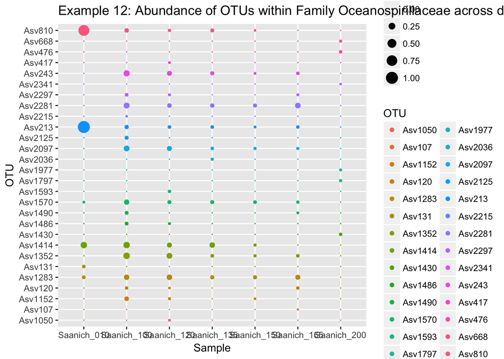

```r
m.perc %>%
  subset_taxa(Family=="D_4__Oceanospirillaceae") %>%
  psmelt() %>%

ggplot() +
  geom_point(aes(x=Sample, y=OTU, size=Abundance, color=OTU)) +
  scale_size_continuous(range = c(0,5)) +
  labs(title="Example 12: Abundance of OTUs within Family Oceanospirillaceae across depth")
```

**Oxygen**

General linear model for each OTU  
Asv107

```r
m.norm %>%
  psmelt() %>%
  filter(OTU=="Asv107") %>%

  lm(Abundance ~ O2_uM, .) %>%
  summary()
```

```
##
## Call:
## lm(formula = Abundance ~ O2_uM, data = .)
##
## Residuals:
##       1       2       3       4       5       6       7
##  4.8244 -0.9410 -1.1756 -1.0274  0.3954 -0.9000 -1.1756
##
## Coefficients:
##              Estimate Std. Error t value Pr(>|t|)
## (Intercept)  1.175639   1.065055   1.104     0.32
## O2_uM       -0.007251   0.012620  -0.575     0.59
##
## Residual standard error: 2.406 on 5 degrees of freedom
## Multiple R-squared:  0.06193,    Adjusted R-squared:  -0.1257
## F-statistic: 0.3301 on 1 and 5 DF,  p-value: 0.5905
```

Asv120

```r
m.norm %>%
  psmelt() %>%
  filter(OTU=="Asv120") %>%

  lm(Abundance ~ O2_uM, .) %>%
  summary()
```

```
##
## Call:
## lm(formula = Abundance ~ O2_uM, data = .)
##
## Residuals:
##        1        2        3        4        5        6        7
##  23.4624  24.6584   0.3315 -15.5376  -3.0208 -14.3564 -15.5376
##
## Coefficients:
##             Estimate Std. Error t value Pr(>|t|)
## (Intercept) 15.53756    8.52995   1.822    0.128
## O2_uM       -0.05777    0.10108  -0.572    0.592
##
## Residual standard error: 19.27 on 5 degrees of freedom
## Multiple R-squared:  0.06133,    Adjusted R-squared:  -0.1264
## F-statistic: 0.3267 on 1 and 5 DF,  p-value: 0.5924
```

Asv131

```r
m.norm %>%
  psmelt() %>%
  filter(OTU=="Asv131") %>%

  lm(Abundance ~ O2_uM, .) %>%
  summary()
```

```
##
## Call:
## lm(formula = Abundance ~ O2_uM, data = .)
##
## Residuals:
##      1      2      3      4      5      6      7
##  1.521  2.768  2.768  2.768 -4.820 -3.690 -1.313
##
## Coefficients:
##             Estimate Std. Error t value Pr(>|t|)
## (Intercept) -2.76761    1.58199  -1.749 0.140622
## O2_uM        0.19960    0.01875  10.648 0.000126 ***
## ---
## Signif. codes:  0 '***' 0.001 '**' 0.01 '*' 0.05 '.' 0.1 ' ' 1
##
## Residual standard error: 3.574 on 5 degrees of freedom
## Multiple R-squared:  0.9578, Adjusted R-squared:  0.9493
## F-statistic: 113.4 on 1 and 5 DF,  p-value: 0.0001264
```

Asv213

```r
m.norm %>%
  psmelt() %>%
  filter(OTU=="Asv213") %>%

  lm(Abundance ~ O2_uM, .) %>%
  summary()
```

```
##
## Call:
## lm(formula = Abundance ~ O2_uM, data = .)
##
## Residuals:
##      1      2      3      4      5      6      7
##  26.64 -73.73 -77.36 -22.86  68.43  49.43  29.43
##
## Coefficients:
##             Estimate Std. Error t value Pr(>|t|)
## (Intercept)  -29.432     28.443  -1.035    0.348
## O2_uM          4.661      0.337  13.828 3.55e-05 ***
## ---
## Signif. codes:  0 '***' 0.001 '**' 0.01 '*' 0.05 '.' 0.1 ' ' 1
##
## Residual standard error: 64.26 on 5 degrees of freedom
## Multiple R-squared:  0.9745, Adjusted R-squared:  0.9694
## F-statistic: 191.2 on 1 and 5 DF,  p-value: 3.552e-05
```

Asv243

```r
m.norm %>%
  psmelt() %>%
  filter(OTU=="Asv243") %>%

  lm(Abundance ~ O2_uM, .) %>%
  summary()
```

```
##
## Call:
## lm(formula = Abundance ~ O2_uM, data = .)
##
## Residuals:
##        1        2        3        4        5        6        7
## 137.9101  46.8673  -0.3275 -30.0958 -52.0958 -71.0958 -31.1625
##
## Coefficients:
##             Estimate Std. Error t value Pr(>|t|)
## (Intercept)  71.0958    34.7763   2.044   0.0963 .
## O2_uM        -0.1843     0.4121  -0.447   0.6734
## ---
## Signif. codes:  0 '***' 0.001 '**' 0.01 '*' 0.05 '.' 0.1 ' ' 1
##
## Residual standard error: 78.56 on 5 degrees of freedom
## Multiple R-squared:  0.03847,    Adjusted R-squared:  -0.1538
## F-statistic:   0.2 on 1 and 5 DF,  p-value: 0.6734
```

Asv417

```r
m.norm %>%
  psmelt() %>%
  filter(OTU=="Asv417") %>%

  lm(Abundance ~ O2_uM, .) %>%
  summary()
```

```
##
## Call:
## lm(formula = Abundance ~ O2_uM, data = .)
##
## Residuals:
##      1      2      3      4      5      6      7
## 17.069 -3.137 -1.757 -3.137 -3.007 -2.895 -3.137
##
## Coefficients:
##              Estimate Std. Error t value Pr(>|t|)
## (Intercept)  3.136820   3.657612   0.858    0.430
## O2_uM       -0.006367   0.043341  -0.147    0.889
##
## Residual standard error: 8.263 on 5 degrees of freedom
## Multiple R-squared:  0.004298,   Adjusted R-squared:  -0.1948
## F-statistic: 0.02158 on 1 and 5 DF,  p-value: 0.8889
```

Asv476

```r
m.norm %>%
  psmelt() %>%
  filter(OTU=="Asv476") %>%

  lm(Abundance ~ O2_uM, .) %>%
  summary()
```

```
##
## Call:
## lm(formula = Abundance ~ O2_uM, data = .)
##
## Residuals:
##      1      2      3      4      5      6      7
## 32.162 -6.274 -6.849 -7.838 -6.000 -7.838  2.636
##
## Coefficients:
##             Estimate Std. Error t value Pr(>|t|)
## (Intercept)  7.83759    7.10036   1.104     0.32
## O2_uM       -0.04834    0.08414  -0.575     0.59
##
## Residual standard error: 16.04 on 5 degrees of freedom
## Multiple R-squared:  0.06193,    Adjusted R-squared:  -0.1257
## F-statistic: 0.3301 on 1 and 5 DF,  p-value: 0.5905
```

Asv668

```r
m.norm %>%
  psmelt() %>%
  filter(OTU=="Asv668") %>%

  lm(Abundance ~ O2_uM, .) %>%
  summary()
```

```
##
## Call:
## lm(formula = Abundance ~ O2_uM, data = .)
##
## Residuals:
##      1      2      3      4      5      6      7
## 20.102 -3.750 -4.898 -4.898 -4.281 -3.921  1.647
##
## Coefficients:
##             Estimate Std. Error t value Pr(>|t|)
## (Intercept)  4.89850    4.43773   1.104     0.32
## O2_uM       -0.03021    0.05258  -0.575     0.59
##
## Residual standard error: 10.03 on 5 degrees of freedom
## Multiple R-squared:  0.06193,    Adjusted R-squared:  -0.1257
## F-statistic: 0.3301 on 1 and 5 DF,  p-value: 0.5905
```

Asv810

```r
m.norm %>%
  psmelt() %>%
  filter(OTU=="Asv810") %>%

  lm(Abundance ~ O2_uM, .) %>%
  summary()
```

```
##
## Call:
## lm(formula = Abundance ~ O2_uM, data = .)
##
## Residuals:
##       1       2       3       4       5       6       7
##  15.177 -34.199   4.559 -64.341  34.934  21.934  21.934
##
## Coefficients:
##             Estimate Std. Error t value Pr(>|t|)
## (Intercept) -21.9345    17.4194  -1.259    0.264
## O2_uM         3.6866     0.2064  17.860 1.01e-05 ***
## ---
## Signif. codes:  0 '***' 0.001 '**' 0.01 '*' 0.05 '.' 0.1 ' ' 1
##
## Residual standard error: 39.35 on 5 degrees of freedom
## Multiple R-squared:  0.9846, Adjusted R-squared:  0.9815
## F-statistic:   319 on 1 and 5 DF,  p-value: 1.01e-05
```

Asv1050

```r
m.norm %>%
  psmelt() %>%
  filter(OTU=="Asv1050") %>%

  lm(Abundance ~ O2_uM, .) %>%
  summary()
```

```
##
## Call:
## lm(formula = Abundance ~ O2_uM, data = .)
##
## Residuals:
##      1      2      3      4      5      6      7
## 13.655 -2.405 -2.509 -1.406 -2.509 -2.316 -2.509
##
## Coefficients:
##              Estimate Std. Error t value Pr(>|t|)
## (Intercept)  2.509456   2.926090   0.858    0.430
## O2_uM       -0.005094   0.034673  -0.147    0.889
##
## Residual standard error: 6.61 on 5 degrees of freedom
## Multiple R-squared:  0.004298,   Adjusted R-squared:  -0.1948
## F-statistic: 0.02158 on 1 and 5 DF,  p-value: 0.8889
```

Asv1152

```r
m.norm %>%
  psmelt() %>%
  filter(OTU=="Asv1152") %>%

  lm(Abundance ~ O2_uM, .) %>%
  summary()
```

```
##
## Call:
## lm(formula = Abundance ~ O2_uM, data = .)
##
## Residuals:
##       1       2       3       4       5       6       7
##  71.188   5.957  -5.360 -11.536 -20.360 -20.360 -19.528
##
## Coefficients:
##             Estimate Std. Error t value Pr(>|t|)
## (Intercept) 20.36044   15.92980   1.278    0.257
## O2_uM       -0.04073    0.18876  -0.216    0.838
##
## Residual standard error: 35.99 on 5 degrees of freedom
## Multiple R-squared:  0.009225,   Adjusted R-squared:  -0.1889
## F-statistic: 0.04656 on 1 and 5 DF,  p-value: 0.8377
```

Asv1283

```r
m.norm %>%
  psmelt() %>%
  filter(OTU=="Asv1283") %>%

  lm(Abundance ~ O2_uM, .) %>%
  summary()
```

```
##
## Call:
## lm(formula = Abundance ~ O2_uM, data = .)
##
## Residuals:
##      1      2      3      4      5      6      7
##  69.21  57.74  26.21 -18.89 -25.79 -18.68 -89.79
##
## Coefficients:
##             Estimate Std. Error t value Pr(>|t|)
## (Intercept) 89.79117   26.73869   3.358   0.0201 *
## O2_uM       -0.09281    0.31684  -0.293   0.7813
## ---
## Signif. codes:  0 '***' 0.001 '**' 0.01 '*' 0.05 '.' 0.1 ' ' 1
##
## Residual standard error: 60.41 on 5 degrees of freedom
## Multiple R-squared:  0.01687,    Adjusted R-squared:  -0.1798
## F-statistic: 0.08581 on 1 and 5 DF,  p-value: 0.7813
```

Asv1352

```r
m.norm %>%
  psmelt() %>%
  filter(OTU=="Asv1352") %>%

  lm(Abundance ~ O2_uM, .) %>%
  summary()
```

```
##
## Call:
## lm(formula = Abundance ~ O2_uM, data = .)
##
## Residuals:
##      1      2      3      4      5      6      7
## 155.42  94.17 -31.44 -39.93 -53.93 -85.93 -38.36
##
## Coefficients:
##             Estimate Std. Error t value Pr(>|t|)
## (Intercept)  85.9292    43.0850   1.994    0.103
## O2_uM        -0.2195     0.5105  -0.430    0.685
##
## Residual standard error: 97.33 on 5 degrees of freedom
## Multiple R-squared:  0.03567,    Adjusted R-squared:  -0.1572
## F-statistic: 0.1849 on 1 and 5 DF,  p-value: 0.6851
```

Asv1414

```r
m.norm %>%
  psmelt() %>%
  filter(OTU=="Asv1414") %>%

  lm(Abundance ~ O2_uM, .) %>%
  summary()
```

```
##
## Call:
## lm(formula = Abundance ~ O2_uM, data = .)
##
## Residuals:
##      1      2      3      4      5      6      7
## -30.79 124.75  63.14  19.71 -40.94 -67.94 -67.94
##
## Coefficients:
##             Estimate Std. Error t value Pr(>|t|)
## (Intercept)  67.9400    35.2983   1.925   0.1122
## O2_uM         0.8762     0.4183   2.095   0.0903 .
## ---
## Signif. codes:  0 '***' 0.001 '**' 0.01 '*' 0.05 '.' 0.1 ' ' 1
##
## Residual standard error: 79.74 on 5 degrees of freedom
## Multiple R-squared:  0.4674, Adjusted R-squared:  0.3609
## F-statistic: 4.389 on 1 and 5 DF,  p-value: 0.09034
```

Asv1430

```r
m.norm %>%
  psmelt() %>%
  filter(OTU=="Asv1430") %>%

  lm(Abundance ~ O2_uM, .) %>%
  summary()
```

```
##
## Call:
## lm(formula = Abundance ~ O2_uM, data = .)
##
## Residuals:
##      1      2      3      4      5      6      7
## 31.358  2.570 -6.117 -5.850 -6.678 -7.642 -7.642
##
## Coefficients:
##             Estimate Std. Error t value Pr(>|t|)
## (Intercept)  7.64165    6.92285   1.104     0.32
## O2_uM       -0.04713    0.08203  -0.575     0.59
##
## Residual standard error: 15.64 on 5 degrees of freedom
## Multiple R-squared:  0.06193,    Adjusted R-squared:  -0.1257
## F-statistic: 0.3301 on 1 and 5 DF,  p-value: 0.5905
```

Asv1486

```r
m.norm %>%
  psmelt() %>%
  filter(OTU=="Asv1486") %>%

  lm(Abundance ~ O2_uM, .) %>%
  summary()
```

```
##
## Call:
## lm(formula = Abundance ~ O2_uM, data = .)
##
## Residuals:
##       1       2       3       4       5       6       7
##  39.770  10.686 -10.794 -10.794 -10.794  -7.583 -10.491
##
## Coefficients:
##             Estimate Std. Error t value Pr(>|t|)
## (Intercept) 10.79384    9.31225   1.159    0.299
## O2_uM       -0.01482    0.11034  -0.134    0.898
##
## Residual standard error: 21.04 on 5 degrees of freedom
## Multiple R-squared:  0.003595,   Adjusted R-squared:  -0.1957
## F-statistic: 0.01804 on 1 and 5 DF,  p-value: 0.8984
```

Asv1490

```r
m.norm %>%
  psmelt() %>%
  filter(OTU=="Asv1490") %>%

  lm(Abundance ~ O2_uM, .) %>%
  summary()
```

```
##
## Call:
## lm(formula = Abundance ~ O2_uM, data = .)
##
## Residuals:
##       1       2       3       4       5       6       7
##  44.240   7.027 -11.321 -11.973 -11.973 -10.941  -5.059
##
## Coefficients:
##             Estimate Std. Error t value Pr(>|t|)
## (Intercept) 11.97305   10.02915   1.194    0.286
## O2_uM       -0.03191    0.11884  -0.269    0.799
##
## Residual standard error: 22.66 on 5 degrees of freedom
## Multiple R-squared:  0.01421,    Adjusted R-squared:  -0.1829
## F-statistic: 0.07209 on 1 and 5 DF,  p-value: 0.799
```

Asv1570

```r
m.norm %>%
  psmelt() %>%
  filter(OTU=="Asv1570") %>%

  lm(Abundance ~ O2_uM, .) %>%
  summary()
```

```
##
## Call:
## lm(formula = Abundance ~ O2_uM, data = .)
##
## Residuals:
##       1       2       3       4       5       6       7
##  81.706   9.986  10.152  -5.017 -23.017 -16.793 -57.017
##
## Coefficients:
##             Estimate Std. Error t value Pr(>|t|)
## (Intercept) 57.01715   20.73066   2.750   0.0403 *
## O2_uM       -0.09796    0.24565  -0.399   0.7065
## ---
## Signif. codes:  0 '***' 0.001 '**' 0.01 '*' 0.05 '.' 0.1 ' ' 1
##
## Residual standard error: 46.83 on 5 degrees of freedom
## Multiple R-squared:  0.03082,    Adjusted R-squared:  -0.163
## F-statistic: 0.159 on 1 and 5 DF,  p-value: 0.7065
```

Asv1593

```r
m.norm %>%
  psmelt() %>%
  filter(OTU=="Asv1593") %>%

  lm(Abundance ~ O2_uM, .) %>%
  summary()
```

```
##
## Call:
## lm(formula = Abundance ~ O2_uM, data = .)
##
## Residuals:
##      1      2      3      4      5      6      7
## 32.431 -5.960 -5.500 -3.339 -5.960 -5.713 -5.960
##
## Coefficients:
##             Estimate Std. Error t value Pr(>|t|)
## (Intercept)  5.95996    6.94946   0.858    0.430
## O2_uM       -0.01210    0.08235  -0.147    0.889
##
## Residual standard error: 15.7 on 5 degrees of freedom
## Multiple R-squared:  0.004298,   Adjusted R-squared:  -0.1948
## F-statistic: 0.02158 on 1 and 5 DF,  p-value: 0.8889
```

Asv1797

```r
m.norm %>%
  psmelt() %>%
  filter(OTU=="Asv1797") %>%

  lm(Abundance ~ O2_uM, .) %>%
  summary()
```

```
##
## Call:
## lm(formula = Abundance ~ O2_uM, data = .)
##
## Residuals:
##      1      2      3      4      5      6      7
## 25.730 -6.270 -5.479 -6.270 -4.800 -5.019  2.109
##
## Coefficients:
##             Estimate Std. Error t value Pr(>|t|)
## (Intercept)  6.27007    5.68029   1.104     0.32
## O2_uM       -0.03867    0.06731  -0.575     0.59
##
## Residual standard error: 12.83 on 5 degrees of freedom
## Multiple R-squared:  0.06193,    Adjusted R-squared:  -0.1257
## F-statistic: 0.3301 on 1 and 5 DF,  p-value: 0.5905
```

Asv1977

```r
m.norm %>%
  psmelt() %>%
  filter(OTU=="Asv1977") %>%

  lm(Abundance ~ O2_uM, .) %>%
  summary()
```

```
##
## Call:
## lm(formula = Abundance ~ O2_uM, data = .)
##
## Residuals:
##      1      2      3      4      5      6      7
## 19.297 -4.110  1.581 -3.600 -4.703 -4.703 -3.764
##
## Coefficients:
##             Estimate Std. Error t value Pr(>|t|)
## (Intercept)  4.70256    4.26022   1.104     0.32
## O2_uM       -0.02900    0.05048  -0.575     0.59
##
## Residual standard error: 9.624 on 5 degrees of freedom
## Multiple R-squared:  0.06193,    Adjusted R-squared:  -0.1257
## F-statistic: 0.3301 on 1 and 5 DF,  p-value: 0.5905
```

Asv2036

```r
m.norm %>%
  psmelt() %>%
  filter(OTU=="Asv2036") %>%

  lm(Abundance ~ O2_uM, .) %>%
  summary()
```

```
##
## Call:
## lm(formula = Abundance ~ O2_uM, data = .)
##
## Residuals:
##       1       2       3       4       5       6       7
## 26.1013 -5.3082 -0.9694 -5.3082 -4.6603 -4.5470 -5.3082
##
## Coefficients:
##             Estimate Std. Error t value Pr(>|t|)
## (Intercept)  5.30818    5.63103   0.943    0.389
## O2_uM       -0.02002    0.06672  -0.300    0.776
##
## Residual standard error: 12.72 on 5 degrees of freedom
## Multiple R-squared:  0.01769,    Adjusted R-squared:  -0.1788
## F-statistic: 0.09007 on 1 and 5 DF,  p-value: 0.7762
```

Asv2097

```r
m.norm %>%
  psmelt() %>%
  filter(OTU=="Asv2097") %>%

  lm(Abundance ~ O2_uM, .) %>%
  summary()
```

```
##
## Call:
## lm(formula = Abundance ~ O2_uM, data = .)
##
## Residuals:
##      1      2      3      4      5      6      7
## 111.45  61.52 -17.44 -31.81 -33.81 -27.09 -62.81
##
## Coefficients:
##             Estimate Std. Error t value Pr(>|t|)
## (Intercept)  62.8128    30.2469   2.077   0.0925 .
## O2_uM        -0.1649     0.3584  -0.460   0.6649
## ---
## Signif. codes:  0 '***' 0.001 '**' 0.01 '*' 0.05 '.' 0.1 ' ' 1
##
## Residual standard error: 68.33 on 5 degrees of freedom
## Multiple R-squared:  0.0406, Adjusted R-squared:  -0.1513
## F-statistic: 0.2116 on 1 and 5 DF,  p-value: 0.6649
```

Asv2125

```r
m.norm %>%
  psmelt() %>%
  filter(OTU=="Asv2125") %>%

  lm(Abundance ~ O2_uM, .) %>%
  summary()
```

```
##
## Call:
## lm(formula = Abundance ~ O2_uM, data = .)
##
## Residuals:
##      1      2      3      4      5      6      7
## 54.796 -7.344 -9.600 -9.600 -9.387 -9.263 -9.600
##
## Coefficients:
##             Estimate Std. Error t value Pr(>|t|)
## (Intercept)  9.60022   11.72301   0.819    0.450
## O2_uM       -0.01041    0.13891  -0.075    0.943
##
## Residual standard error: 26.48 on 5 degrees of freedom
## Multiple R-squared:  0.001122,   Adjusted R-squared:  -0.1987
## F-statistic: 0.005619 on 1 and 5 DF,  p-value: 0.9432
```

Asv2215

```r
m.norm %>%
  psmelt() %>%
  filter(OTU=="Asv2215") %>%

  lm(Abundance ~ O2_uM, .) %>%
  summary()
```

```
##
## Call:
## lm(formula = Abundance ~ O2_uM, data = .)
##
## Residuals:
##      1      2      3      4      5      6      7
##  9.418 -1.613 -1.650 -1.650 -1.262 -1.650 -1.592
##
## Coefficients:
##             Estimate Std. Error t value Pr(>|t|)
## (Intercept)  1.65004    2.01489   0.819    0.450
## O2_uM       -0.00179    0.02388  -0.075    0.943
##
## Residual standard error: 4.552 on 5 degrees of freedom
## Multiple R-squared:  0.001122,   Adjusted R-squared:  -0.1987
## F-statistic: 0.005619 on 1 and 5 DF,  p-value: 0.9432
```

Asv2281

```r
m.norm %>%
  psmelt() %>%
  filter(OTU=="Asv2281") %>%

  lm(Abundance ~ O2_uM, .) %>%
  summary()
```

```
##
## Call:
## lm(formula = Abundance ~ O2_uM, data = .)
##
## Residuals:
##       1       2       3       4       5       6       7
##  96.380  60.291   4.283 -12.131 -35.709 -16.404 -96.709
##
## Coefficients:
##             Estimate Std. Error t value Pr(>|t|)
## (Intercept)  96.7092    30.6591   3.154   0.0253 *
## O2_uM        -0.3706     0.3633  -1.020   0.3544
## ---
## Signif. codes:  0 '***' 0.001 '**' 0.01 '*' 0.05 '.' 0.1 ' ' 1
##
## Residual standard error: 69.26 on 5 degrees of freedom
## Multiple R-squared:  0.1723, Adjusted R-squared:  0.006764
## F-statistic: 1.041 on 1 and 5 DF,  p-value: 0.3544
```

Asv2297

```r
m.norm %>%
  psmelt() %>%
  filter(OTU=="Asv2297") %>%

  lm(Abundance ~ O2_uM, .) %>%
  summary()
```

```
##
## Call:
## lm(formula = Abundance ~ O2_uM, data = .)
##
## Residuals:
##       1       2       3       4       5       6       7
##  33.467  10.230   6.875  -6.052 -14.269 -15.125 -15.125
##
## Coefficients:
##             Estimate Std. Error t value Pr(>|t|)
## (Intercept) 15.12503    8.78569   1.722    0.146
## O2_uM       -0.04187    0.10411  -0.402    0.704
##
## Residual standard error: 19.85 on 5 degrees of freedom
## Multiple R-squared:  0.03134,    Adjusted R-squared:  -0.1624
## F-statistic: 0.1618 on 1 and 5 DF,  p-value: 0.7041
```

Asv2341

```r
m.norm %>%
  psmelt() %>%
  filter(OTU=="Asv2341") %>%

  lm(Abundance ~ O2_uM, .) %>%
  summary()
```

```
##
## Call:
## lm(formula = Abundance ~ O2_uM, data = .)
##
## Residuals:
##       1       2       3       4       5       6       7
##  9.6487 -2.0548 -1.8821 -2.3513 -2.3513  0.7907 -1.8000
##
## Coefficients:
##             Estimate Std. Error t value Pr(>|t|)
## (Intercept)  2.35128    2.13011   1.104     0.32
## O2_uM       -0.01450    0.02524  -0.575     0.59
##
## Residual standard error: 4.812 on 5 degrees of freedom
## Multiple R-squared:  0.06193,    Adjusted R-squared:  -0.1257
## F-statistic: 0.3301 on 1 and 5 DF,  p-value: 0.5905
```

**Repeat for all OTUs within domain and then correct for multiple comparisons.**

This is all made up p-values.

```r
p.adjust(c(0.501, 0.031, 0.005, 0.324), method="fdr")
```

```
## [1] 0.501 0.062 0.020 0.432
```

Plots to go along with these tests.

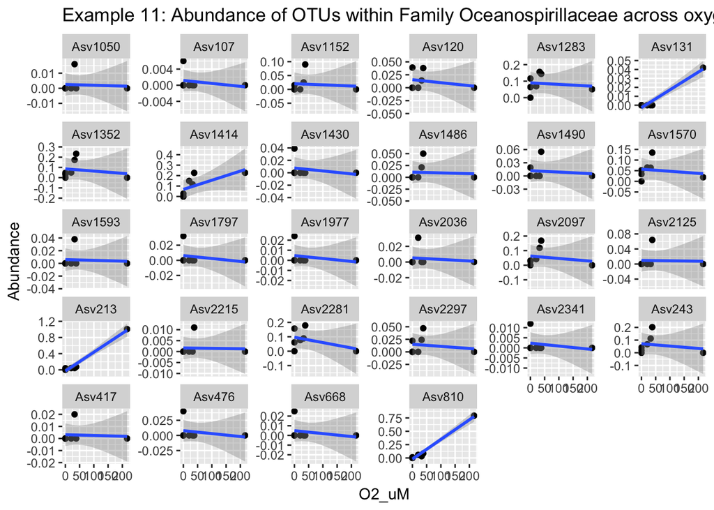

```r
m.perc %>%
  subset_taxa(Family=="D_4__Oceanospirillaceae") %>%
  psmelt() %>%

ggplot() +
  geom_point(aes(x=O2_uM, y=Abundance)) +
  geom_smooth(method='lm', aes(x=O2_uM, y=Abundance)) +
  facet_wrap(~OTU, scales="free_y") +
  labs(title="Example 11: Abundance of OTUs within Family Oceanospirillaceae across oxygen")
```

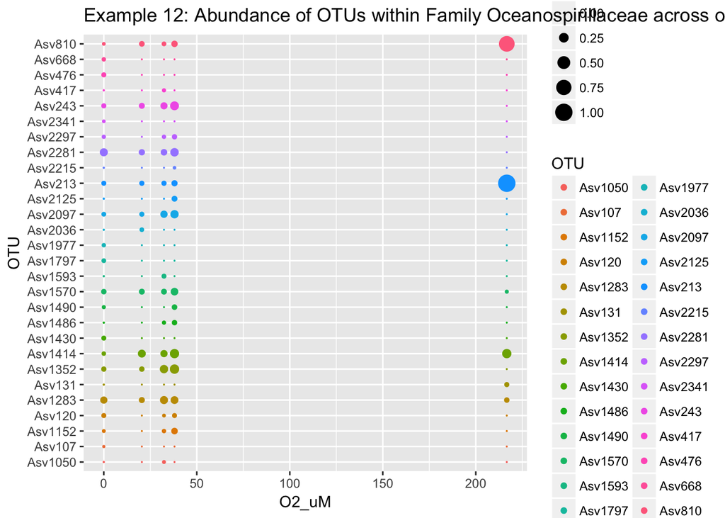

```r
m.perc %>%
  subset_taxa(Family=="D_4__Oceanospirillaceae") %>%
  psmelt() %>%

ggplot() +
  geom_point(aes(x=O2_uM, y=OTU, size=Abundance, color=OTU)) +
  scale_size_continuous(range = c(0,5)) +
  labs(title="Example 12: Abundance of OTUs within Family Oceanospirillaceae across oxygen")
```

## Are the answers to the above the same using mothur and QIIME2 processed data?

# Discussion

# References